# Multispecies occupancy models in `unmarked`

# Outline

1. Model review
2. Fit model with `unmarked`
3. Marginal and conditional occupancy
4. Model fitting challenges

# Model review

- Suppose you sample for $S = 2$ species at N sites, $i=1...N$
- Then the latent state $\textbf{Z}_i$ at site $i$ is a vector of length 2, and there are four possible states:

$$ \textbf{Z}_i = \{11\}, \{10\},\{01\}, or \{00\} $$

$$ \textbf{Z}_i \sim \mathrm{MultivariateBernoulli}(\boldsymbol\psi) $$

$$ pr(Z_i) = \{11\} \Longrightarrow \psi_{11} $$ $$ pr(Z_i) = \{10\} \Longrightarrow \psi_{10} $$ $$ pr(Z_i) = \{01\} \Longrightarrow \psi_{01} $$ $$ pr(Z_i) = \{00\} \Longrightarrow \psi_{00} $$

$$ \sum{\boldsymbol\psi} = 1$$

### How do we get the values of $\psi$?

### Start with the "natural parameters", $f$

$f_1$: Term associated with occupancy of species 1 by itself

$f_2$: Term associated with occupancy of species 2 by itself

$f_{12}$: Interaction term between the two species

If $f_{12}$ is positive, presence of one species increases occupancy probability of the other

If $f_{12}$ is negative, presence of one species decreases occupancy probability of the other

### Calculating $\psi$: the multinomial logit link

Each element of $\mathbf{\psi}$ is a function of the natural parameters $f$.

$$ \begin{align} \psi_{11} & \propto exp(f_{1} + f_{2} + f_{12}) \\ \psi_{10} & \propto exp(f_{1}) \\ \psi_{01} & \propto exp(f_{2}) \\ \psi_{00} & \propto exp(0) = 1 \end{align} $$

Making sure $\mathbf{\psi}$ sums to 1:

$$ \psi_{11} = \frac{exp(f_{1} + f_{2} + f_{12})}{1 + exp(f_{1}) + exp(f_{2}) + exp(f_{1} + f_{2} + f_{12})} $$

$$ \psi_{10} = \frac{exp(f_{1})}{1 + exp(f_{1}) + exp(f_{2}) + exp(f_{1} + f_{2} + f_{12})} $$

$$ \psi_{01} = \frac{exp(f_{2})}{1 + exp(f_{1}) + exp(f_{2}) + exp(f_{1} + f_{2} + f_{12})} $$

$$ \psi_{00} = \frac{1}{1 + exp(f_{1}) + exp(f_{2}) + exp(f_{1} + f_{2} + f_{12})} $$

### A note on removing interaction terms

Original math:

$$ \begin{align} \psi_{11} & \propto exp(f_{1} + f_{2} + f_{12}) \\ \psi_{10} & \propto exp(f_{1}) \\ \psi_{01} & \propto exp(f_{2}) \\ \psi_{00} & \propto 1 \end{align} $$

What if we force $f_{12} = 0$?

$$ \begin{align} \psi_{11} & \propto exp(f_{1} + f_{2}) \\ \psi_{10} & \propto exp(f_{1}) \\ \psi_{01} & \propto exp(f_{2}) \\ \psi_{00} & \propto 1 \end{align} $$

This is equivalent to fitting two separate occupancy models. I'll show this later.

### Modeling detection

- It's the same as single-species occupancy
- Each species gets its own separate detection model

For example, detection/nondetection of species 1 at site $i$ and occasion $j$ can be modeled as

$$ y_{1,ij} \sim \mathrm{Bernoulli}(p_{1} \cdot z_{1,i}) $$

where $z_{1,i}$ is the element 1 of $Z_i$ (i.e., latent presence/absence of species 1 at site $i$) and $p_{1}$ is the species 1 detection probability

# Multispecies occupancy model in `unmarked`

```r
library(unmarked)
```

We will use the function `occuMulti`

[figure not shown]

## Set up the input data

### Example data

```r
data(MesoCarnivores)
lapply(MesoCarnivores, head) # look at raw data
```

**$bobcat**

A matrix: 6 × 3 of type int

| X1 | X2 | X3 |
| --- | --- | --- |
| 0 | 0 | 0 |
| 0 | 0 | 0 |
| 0 | 0 | 0 |
| 0 | 0 | 0 |
| 0 | 0 | 0 |
| 0 | 0 | 0 |

**$coyote**

A matrix: 6 × 3 of type int

| X1 | X2 | X3 |
| --- | --- | --- |
| 0 | 0 | 0 |
| 0 | 0 | 0 |
| 0 | 0 | 0 |
| 0 | 0 | 0 |
| 0 | 0 | 0 |
| 0 | 0 | 0 |

**$redfox**

A matrix: 6 × 3 of type int

| X1 | X2 | X3 |
| --- | --- | --- |
| 0 | 0 | 0 |
| 0 | 0 | 0 |
| 0 | 0 | 1 |
| 0 | 0 | 0 |
| 0 | 0 | 0 |
| 1 | 1 | 1 |

**$sitecovs**

A data.frame: 6 × 6

|  | Dist_5km <dbl> | HDens_5km <dbl> | Latitude <dbl> | Longitude <dbl> | People_site <dbl> | Trail <int> |
| --- | --- | --- | --- | --- | --- | --- |
| 1 | 0.04 | 9.345258 | 0.3899441 | -0.7723958 | 0.857 | 1 |
| 2 | 0.03 | 9.499197 | 0.3899250 | -0.7723920 | 0.002 | 0 |
| 3 | 0.03 | 9.647173 | 0.3899111 | -0.7723954 | 0.387 | 1 |
| 4 | 0.03 | 9.598066 | 0.3899166 | -0.7723972 | 0.003 | 0 |
| 5 | 0.03 | 9.607825 | 0.3899179 | -0.7724004 | 0.000 | 0 |
| 6 | 0.03 | 9.748791 | 0.3899058 | -0.7724046 | 0.443 | 1 |

### Formatting the data

We will create an `unmarkedFrameOccuMulti`.

The main difference from `unmarkedFrameOccu` is that you have >1 matrix of observations: we now have one `y` per species.

[figure not shown]

Get some more detail by looking at the help file for `unmarkedFrameOccuMulti`:

```r
?unmarkedFrameOccuMulti
```

### y list

The first three elements of `MesoCarnivores` are the y-matrices. To keep things simple, we'll just use coyote and red fox.

Notice that the resulting list is **named**: this is important!

```r
ylist <- MesoCarnivores[c(2:3)]
lapply(ylist, head) # look at first few rows
```

**$coyote**

A matrix: 6 × 3 of type int

| X1 | X2 | X3 |
| --- | --- | --- |
| 0 | 0 | 0 |
| 0 | 0 | 0 |
| 0 | 0 | 0 |
| 0 | 0 | 0 |
| 0 | 0 | 0 |
| 0 | 0 | 0 |

**$redfox**

A matrix: 6 × 3 of type int

| X1 | X2 | X3 |
| --- | --- | --- |
| 0 | 0 | 0 |
| 0 | 0 | 0 |
| 0 | 0 | 1 |
| 0 | 0 | 0 |
| 0 | 0 | 0 |
| 1 | 1 | 1 |

### Site covariates

The last element of the `MesoCarnivores` list is a data frame of site covariates:

```r
site_covs <- MesoCarnivores$sitecovs
head(site_covs)
```

A data.frame: 6 × 6

|  | Dist_5km <dbl> | HDens_5km <dbl> | Latitude <dbl> | Longitude <dbl> | People_site <dbl> | Trail <int> |
| --- | --- | --- | --- | --- | --- | --- |
| 1 | 0.04 | 9.345258 | 0.3899441 | -0.7723958 | 0.857 | 1 |
| 2 | 0.03 | 9.499197 | 0.3899250 | -0.7723920 | 0.002 | 0 |
| 3 | 0.03 | 9.647173 | 0.3899111 | -0.7723954 | 0.387 | 1 |
| 4 | 0.03 | 9.598066 | 0.3899166 | -0.7723972 | 0.003 | 0 |
| 5 | 0.03 | 9.607825 | 0.3899179 | -0.7724004 | 0.000 | 0 |
| 6 | 0.03 | 9.748791 | 0.3899058 | -0.7724046 | 0.443 | 1 |

### Construct the unmarked frame

```r
umf <- unmarkedFrameOccuMulti(y=ylist, siteCovs=site_covs)
head(umf)
```

```
Data frame representation of unmarkedFrame object.
Only showing observation matrix for species 1.
   y.1 y.2 y.3 Dist_5km HDens_5km  Latitude  Longitude People_site Trail
1    0   0   0     0.04  9.345258 0.3899441 -0.7723958       0.857     1
2    0   0   0     0.03  9.499197 0.3899250 -0.7723920       0.002     0
3    0   0   0     0.03  9.647173 0.3899111 -0.7723954       0.387     1
4    0   0   0     0.03  9.598066 0.3899166 -0.7723972       0.003     0
5    0   0   0     0.03  9.607825 0.3899179 -0.7724004       0.000     0
6    0   0   0     0.03  9.748791 0.3899058 -0.7724046       0.443     1
7    0   0   0     0.03  9.715359 0.3899097 -0.7724065       0.000     0
8    0   0   0     0.03  9.685091 0.3899135 -0.7724103       0.000     0
9    0   0   0     0.04  9.051558 0.3899955 -0.7724561       0.002     0
10   0   0   0     0.04  9.031836 0.3899971 -0.7724504       0.000     0
```

```r
summary(umf)
```

```
unmarkedFrame Object

1437 sites
2 species: coyote redfox
Maximum number of observations per site: 3
Mean number of observations per site:
coyote: 3  redfox: 3
Sites with at least one detection:
coyote: 401  redfox: 161
Tabulation of y observations:
coyote:
   0    1
3685  626
redfox:
   0    1
4054  257

Site-level covariates:
    Dist_5km         HDens_5km           Latitude        Longitude
 Min.   :0.00000   Min.   :  0.0000   Min.   :0.3454   Min.   :-0.8539
 1st Qu.:0.00000   1st Qu.:  0.2073   1st Qu.:0.3567   1st Qu.:-0.8009
 Median :0.00000   Median :  0.7310   Median :0.3753   Median :-0.7940
 Mean   :0.01419   Mean   :  8.4532   Mean   :0.3726   Mean   :-0.7969
 3rd Qu.:0.02000   3rd Qu.:  3.0219   3rd Qu.:0.3863   3rd Qu.:-0.7801
 Max.   :0.13000   Max.   :186.6694   Max.   :0.3967   Max.   :-0.7690
  People_site          Trail
 Min.   :0.00000   Min.   :0.0000
 1st Qu.:0.00000   1st Qu.:0.0000
 Median :0.00000   Median :0.0000
 Mean   :0.05807   Mean   :0.3229
 3rd Qu.:0.00900   3rd Qu.:1.0000
 Max.   :2.44100   Max.   :1.0000
```

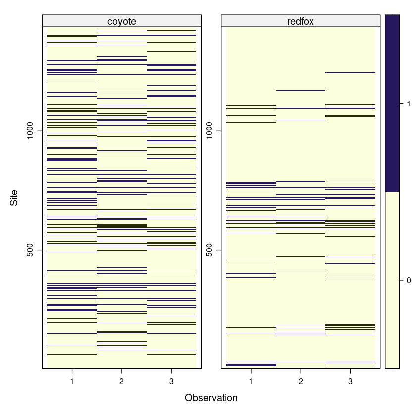

```r
plot(umf)
```

## Set up the formulas

[figure not shown]

### `stateformulas`

While `occu` had a single formula for occupancy, `occuMulti` requires one formula per natural parameter $f$, organized into a `stateformulas` vector.

It can be hard to keep track of how many natural parameters there are and what each one represents.

It can be helpful to look at the $f$-design matrix, which is generated by `unmarkedFrameOccuMulti`.

```r
umf@fDesign
```

A matrix: 4 × 3 of type dbl

|  | f1[coyote] | f2[redfox] | f3[coyote:redfox] |
| --- | --- | --- | --- |
| psi[11] | 1 | 1 | 1 |
| psi[10] | 1 | 0 | 0 |
| psi[01] | 0 | 1 | 0 |
| psi[00] | 0 | 0 | 0 |

The number and order of the formulas in the `stateformulas` vector should match the column names of this matrix. Therefore we'll need 3 formulas total. For this model we'll set the 1st-order $f$ parameters to be a function of (standardized) housing density. The interaction term will be intercept-only.

Our `stateformulas` should look like this:

```r
stateformulas <- c("~scale(HDens_5km)","~scale(HDens_5km)","~1")
stateformulas
```

1. '~scale(HDens_5km)'

2. '~scale(HDens_5km)'

3. '~1'

Notice that the formulas are **strings** (each wrapped in `""`). This is required and is just working around some R limitations.

### `detformulas`

This one is easier, there is just one formula per species, so there should be 2 total.

Intercept-only models for both species:

```r
detformulas <- c("~1","~1")
detformulas
```

1. '~1'

2. '~1'

## Run `occuMulti`

We now have all the pieces we need (`unmarkedFrameOccuMulti`, `stateformulas`, `detformulas`) needed to run a model.

```r
?occuMulti
```

```r
mod_hdens <- occuMulti(detformulas=detformulas, stateformulas=stateformulas, data=umf)
mod_hdens
```

```
Call:
occuMulti(detformulas = detformulas, stateformulas = stateformulas,
    data = umf, maxOrder = 2L)

Occupancy:
                             Estimate     SE         z  P(>|z|)
[coyote] (Intercept)        -0.786370 0.0815  -9.64306 5.26e-22
[coyote] scale(HDens_5km)   -0.000668 0.0691  -0.00966 9.92e-01
[redfox] (Intercept)        -2.391812 0.1598 -14.96684 1.21e-50
[redfox] scale(HDens_5km)    0.504456 0.0813   6.20113 5.61e-10
[coyote:redfox] (Intercept)  1.062921 0.2322   4.57859 4.68e-06

Detection:
                     Estimate     SE     z  P(>|z|)
[coyote] (Intercept)   -0.333 0.0764 -4.36 1.31e-05
[redfox] (Intercept)   -0.251 0.1180 -2.13 3.34e-02

AIC: 4800.859
```

## Model goodness-of-fit

Fit statistic: sum of squared errors (SSE) across all species

$$ SSE = \sum_{s=1}^S \sum_{i=1}^{M\cdot J} \left(y_{i} - \hat{y}_{i}\right)^2 $$

$$ \hat{y}_i = \psi_{marg_i} \cdot p_i $$

$\psi_{marg_i}$ is the marginal occupancy for the species (I'll talk about it more in a minute)

Run a parametric bootstrap (takes a while):

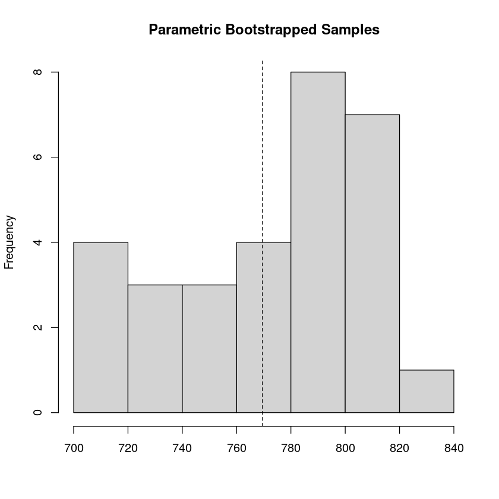

```r
pb <- parboot(mod_hdens, nsim=30)
plot(pb)
```

Dotted line (real dataset) should fall within the histogram (simulated datasets).

There isn't a function available for the MB test for multispecies models (yet?)

## Inference

```r
mod_hdens
```

```
Call:
occuMulti(detformulas = detformulas, stateformulas = stateformulas,
    data = umf, maxOrder = 2L)

Occupancy:
                             Estimate     SE         z  P(>|z|)
[coyote] (Intercept)        -0.786370 0.0815  -9.64306 5.26e-22
[coyote] scale(HDens_5km)   -0.000668 0.0691  -0.00966 9.92e-01
[redfox] (Intercept)        -2.391812 0.1598 -14.96684 1.21e-50
[redfox] scale(HDens_5km)    0.504456 0.0813   6.20113 5.61e-10
[coyote:redfox] (Intercept)  1.062921 0.2322   4.57859 4.68e-06

Detection:
                     Estimate     SE     z  P(>|z|)
[coyote] (Intercept)   -0.333 0.0764 -4.36 1.31e-05
[redfox] (Intercept)   -0.251 0.1180 -2.13 3.34e-02

AIC: 4800.859
```

- Coyote occupancy is higher than red fox
- No relationship between coyote occupancy and housing density
- Positive relationship between red fox and housing density
- Positive interaction between coyote and fox

### Exercise

- Add `Dist_5km` (disturbance) as a site-level covariate on one or more occupancy parameters
- Add `Trail` as a covariate on detection probability for both species
- Name the model object `mod_dist`
- If you have time, check goodness-of-fit with `parboot`

```r
head(umf)
```

```
Data frame representation of unmarkedFrame object.
Only showing observation matrix for species 1.
   y.1 y.2 y.3 Dist_5km HDens_5km  Latitude  Longitude People_site Trail
1    0   0   0     0.04  9.345258 0.3899441 -0.7723958       0.857     1
2    0   0   0     0.03  9.499197 0.3899250 -0.7723920       0.002     0
3    0   0   0     0.03  9.647173 0.3899111 -0.7723954       0.387     1
4    0   0   0     0.03  9.598066 0.3899166 -0.7723972       0.003     0
5    0   0   0     0.03  9.607825 0.3899179 -0.7724004       0.000     0
6    0   0   0     0.03  9.748791 0.3899058 -0.7724046       0.443     1
7    0   0   0     0.03  9.715359 0.3899097 -0.7724065       0.000     0
8    0   0   0     0.03  9.685091 0.3899135 -0.7724103       0.000     0
9    0   0   0     0.04  9.051558 0.3899955 -0.7724561       0.002     0
10   0   0   0     0.04  9.031836 0.3899971 -0.7724504       0.000     0
```

### Occupancy probabilities

To get the expected probability $\boldsymbol\psi$ for each occupancy state at each site, use `predict`. This gives you the probabilities along with standard errors and a 95% CI.

```r
occ_prob <- predict(mod_hdens, type="state")
lapply(occ_prob, head)
```

```
Bootstrapping confidence intervals with 100 samples
```

**$Predicted**

A matrix: 6 × 4 of type dbl

| psi[11] | psi[10] | psi[01] | psi[00] |
| --- | --- | --- | --- |
| 0.07332333 | 0.2725955 | 0.05560920 | 0.5984720 |
| 0.07349727 | 0.2724991 | 0.05574131 | 0.5982624 |
| 0.07366480 | 0.2724062 | 0.05586856 | 0.5980605 |
| 0.07360916 | 0.2724370 | 0.05582630 | 0.5981275 |
| 0.07362022 | 0.2724309 | 0.05583470 | 0.5981142 |
| 0.07378003 | 0.2723423 | 0.05595609 | 0.5979216 |

**$SE**

A matrix: 6 × 4 of type dbl

| psi[11] | psi[10] | psi[01] | psi[00] |
| --- | --- | --- | --- |
| 0.009586875 | 0.01574009 | 0.008862727 | 0.01695695 |
| 0.009608904 | 0.01575760 | 0.008880414 | 0.01697285 |
| 0.009630185 | 0.01577470 | 0.008897499 | 0.01698836 |
| 0.009623111 | 0.01576899 | 0.008891820 | 0.01698319 |
| 0.009624516 | 0.01577013 | 0.008892948 | 0.01698421 |
| 0.009644859 | 0.01578660 | 0.008909280 | 0.01699913 |

**$lower**

A matrix: 6 × 4 of type dbl

| psi[11] | psi[10] | psi[01] | psi[00] |
| --- | --- | --- | --- |
| 0.05866341 | 0.2494024 | 0.04279891 | 0.5622790 |
| 0.05879536 | 0.2492437 | 0.04290091 | 0.5620844 |
| 0.05892243 | 0.2490911 | 0.04299916 | 0.5618970 |
| 0.05888024 | 0.2491418 | 0.04296653 | 0.5619593 |
| 0.05888862 | 0.2491317 | 0.04297301 | 0.5619469 |
| 0.05900984 | 0.2489862 | 0.04306674 | 0.5617682 |

**$upper**

A matrix: 6 × 4 of type dbl

| psi[11] | psi[10] | psi[01] | psi[00] |
| --- | --- | --- | --- |
| 0.09426301 | 0.3047350 | 0.07553358 | 0.6261410 |
| 0.09445900 | 0.3047240 | 0.07570687 | 0.6260587 |
| 0.09464773 | 0.3047134 | 0.07587376 | 0.6259791 |
| 0.09458506 | 0.3047170 | 0.07581834 | 0.6260056 |
| 0.09459751 | 0.3047163 | 0.07582935 | 0.6260003 |
| 0.09477752 | 0.3047061 | 0.07598854 | 0.6259241 |

Rows should sum to 1:

```r
head(apply(occ_prob$Predicted, 1, sum))
```

1. 1

2. 1

3. 1

4. 1

5. 1

6. 1

### Marginal occupancy

You might want to know the *marginal* occupancy of species 2 (red fox) at a site, which is the probability of red fox occupancy regardless of the occupancy states of other species.

This is calculated by summing all $\psi$ states in which red fox is present:

$$ \psi_{marg,i2} = \psi_{11}+\psi_{01} $$

Calculate manually:

```r
head(occ_prob$Predicted)
```

A matrix: 6 × 4 of type dbl

| psi[11] | psi[10] | psi[01] | psi[00] |
| --- | --- | --- | --- |
| 0.07332333 | 0.2725955 | 0.05560920 | 0.5984720 |
| 0.07349727 | 0.2724991 | 0.05574131 | 0.5982624 |
| 0.07366480 | 0.2724062 | 0.05586856 | 0.5980605 |
| 0.07360916 | 0.2724370 | 0.05582630 | 0.5981275 |
| 0.07362022 | 0.2724309 | 0.05583470 | 0.5981142 |
| 0.07378003 | 0.2723423 | 0.05595609 | 0.5979216 |

```r
marg_manual <- occ_prob$Predicted[,1] + occ_prob$Predicted[,3]
head(marg_manual)
```

1. 0.128932527289864

2. 0.129238577153034

3. 0.129533355983501

4. 0.12943546866351

5. 0.12945491792695

6. 0.129736118142071

You can also do this by specifying the `species` argument in `predict`.

```r
redfox_marginal <- predict(mod_hdens, type="state", species="redfox")
head(redfox_marginal)
```

```
Bootstrapping confidence intervals with 100 samples
```

A data.frame: 6 × 4

|  | Predicted <dbl> | SE <dbl> | lower <dbl> | upper <dbl> |
| --- | --- | --- | --- | --- |
| 1 | 0.1289325 | 0.01005935 | 0.1130880 | 0.1541994 |
| 2 | 0.1292386 | 0.01007552 | 0.1133038 | 0.1545102 |
| 3 | 0.1295334 | 0.01009127 | 0.1135116 | 0.1548094 |
| 4 | 0.1294355 | 0.01008602 | 0.1134426 | 0.1547101 |
| 5 | 0.1294549 | 0.01008706 | 0.1134564 | 0.1547298 |
| 6 | 0.1297361 | 0.01010220 | 0.1136545 | 0.1550152 |

#### Plotting marginal occupancy

Compare across species (at site 1 only) with a plot:

```r
coy_marginal <- predict(mod_hdens, type='state', species="coyote") # get coyote

marg_plot_dat <- rbind(redfox_marginal[1,], coy_marginal[1,])
marg_plot_dat$Species <- c("Red fox", "Coyote")
marg_plot_dat
```

```
Bootstrapping confidence intervals with 100 samples
```

A data.frame: 2 × 5

| Predicted <dbl> | SE <dbl> | lower <dbl> | upper <dbl> | Species <chr> |
| --- | --- | --- | --- | --- |
| 0.1289325 | 0.01005935 | 0.1130880 | 0.1541994 | Red fox |
| 0.3459189 | 0.01911216 | 0.3132635 | 0.3777332 | Coyote |

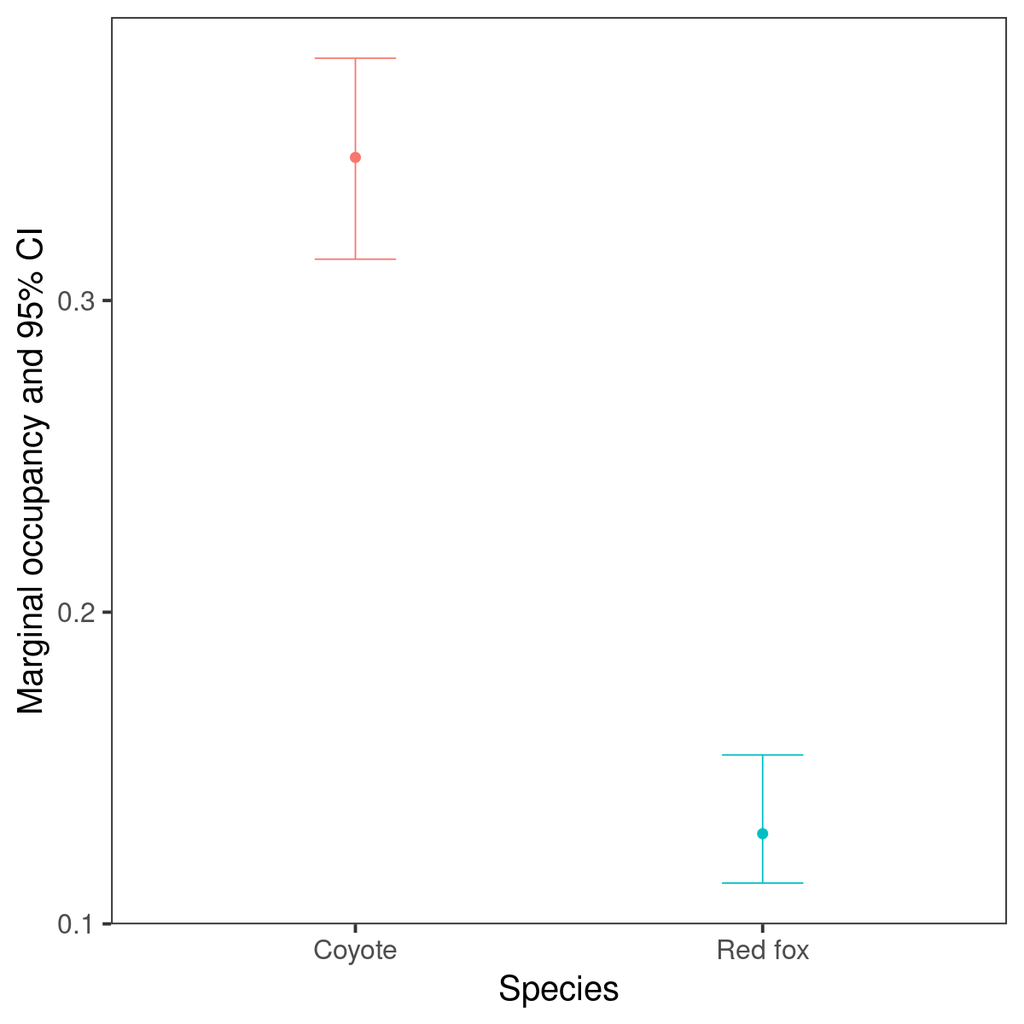

```r
library(ggplot2)
options(repr.plot.width=10, repr.plot.height=10)

ggplot(data = marg_plot_dat, aes(x=Species, col=Species)) +
  geom_errorbar(aes(ymin=lower, ymax=upper), width = 0.2) +
  geom_point(aes(y=Predicted), size=3) +
  theme_bw(base_size=24) +
  theme(panel.grid = element_blank(), legend.position='none') +
  labs(y = "Marginal occupancy and 95% CI", x = "Species")
```

### Conditional occupancy

Alternatively, you might want to know the probability of occupancy of one species, conditional on the presence of another.

For example, the probability of red fox occupancy, conditional on coyote presence:

$$ \psi_{i, fox, coy} = \frac{\psi_{i{11}}}{\psi_{i{10}} + \psi_{i{11}}}$$

```r
lapply(occ_prob, head)
```

**$Predicted**

A matrix: 6 × 4 of type dbl

| psi[11] | psi[10] | psi[01] | psi[00] |
| --- | --- | --- | --- |
| 0.07332333 | 0.2725955 | 0.05560920 | 0.5984720 |
| 0.07349727 | 0.2724991 | 0.05574131 | 0.5982624 |
| 0.07366480 | 0.2724062 | 0.05586856 | 0.5980605 |
| 0.07360916 | 0.2724370 | 0.05582630 | 0.5981275 |
| 0.07362022 | 0.2724309 | 0.05583470 | 0.5981142 |
| 0.07378003 | 0.2723423 | 0.05595609 | 0.5979216 |

**$SE**

A matrix: 6 × 4 of type dbl

| psi[11] | psi[10] | psi[01] | psi[00] |
| --- | --- | --- | --- |
| 0.009586875 | 0.01574009 | 0.008862727 | 0.01695695 |
| 0.009608904 | 0.01575760 | 0.008880414 | 0.01697285 |
| 0.009630185 | 0.01577470 | 0.008897499 | 0.01698836 |
| 0.009623111 | 0.01576899 | 0.008891820 | 0.01698319 |
| 0.009624516 | 0.01577013 | 0.008892948 | 0.01698421 |
| 0.009644859 | 0.01578660 | 0.008909280 | 0.01699913 |

**$lower**

A matrix: 6 × 4 of type dbl

| psi[11] | psi[10] | psi[01] | psi[00] |
| --- | --- | --- | --- |
| 0.05866341 | 0.2494024 | 0.04279891 | 0.5622790 |
| 0.05879536 | 0.2492437 | 0.04290091 | 0.5620844 |
| 0.05892243 | 0.2490911 | 0.04299916 | 0.5618970 |
| 0.05888024 | 0.2491418 | 0.04296653 | 0.5619593 |
| 0.05888862 | 0.2491317 | 0.04297301 | 0.5619469 |
| 0.05900984 | 0.2489862 | 0.04306674 | 0.5617682 |

**$upper**

A matrix: 6 × 4 of type dbl

| psi[11] | psi[10] | psi[01] | psi[00] |
| --- | --- | --- | --- |
| 0.09426301 | 0.3047350 | 0.07553358 | 0.6261410 |
| 0.09445900 | 0.3047240 | 0.07570687 | 0.6260587 |
| 0.09464773 | 0.3047134 | 0.07587376 | 0.6259791 |
| 0.09458506 | 0.3047170 | 0.07581834 | 0.6260056 |
| 0.09459751 | 0.3047163 | 0.07582935 | 0.6260003 |
| 0.09477752 | 0.3047061 | 0.07598854 | 0.6259241 |

```r
cond_manual <- occ_prob$Predicted[,1] / (occ_prob$Predicted[,2] + occ_prob$Predicted[,1])
head(cond_manual)
```

1. 0.211966855711672

2. 0.212422094431736

3. 0.212860373412584

4. 0.212714855095836

5. 0.212743769851648

6. 0.213161730738218

And on coyote absence:

$$ \psi_{i, fox, -coy} = \frac{\psi_{i{01}}}{\psi_{i{01}} + \psi_{i{00}}}$$

```r
cond_manual <- occ_prob$Predicted[,3] / (occ_prob$Predicted[,3] + occ_prob$Predicted[,4])
head(cond_manual)
```

1. 0.085018802685836

2. 0.0852308848711668

3. 0.0854352047664343

4. 0.0853673509389007

5. 0.0853808324230693

6. 0.0855757726311217

With `predict`, use the `species` and `cond` arguments together for this.

```r
redfox_coy <- predict(mod_hdens, type="state", species="redfox", cond="coyote")
head(redfox_coy)
```

```
Bootstrapping confidence intervals with 100 samples
```

A data.frame: 6 × 4

|  | Predicted <dbl> | SE <dbl> | lower <dbl> | upper <dbl> |
| --- | --- | --- | --- | --- |
| 1 | 0.2119669 | 0.02574245 | 0.1571972 | 0.2513897 |
| 2 | 0.2124221 | 0.02578589 | 0.1575106 | 0.2519562 |
| 3 | 0.2128604 | 0.02582784 | 0.1578123 | 0.2525015 |
| 4 | 0.2127149 | 0.02581390 | 0.1577121 | 0.2523205 |
| 5 | 0.2127438 | 0.02581667 | 0.1577320 | 0.2523565 |
| 6 | 0.2131617 | 0.02585676 | 0.1580198 | 0.2528765 |

What about conditional on coyote *absence*?

Use `-`

```r
redfox_nocoy <- predict(mod_hdens, type="state", species="redfox", cond="-coyote")
head(redfox_nocoy)
```

```
Bootstrapping confidence intervals with 100 samples
```

A data.frame: 6 × 4

|  | Predicted <dbl> | SE <dbl> | lower <dbl> | upper <dbl> |
| --- | --- | --- | --- | --- |
| 1 | 0.08501880 | 0.01422803 | 0.06286581 | 0.1210114 |
| 2 | 0.08523088 | 0.01426298 | 0.06299720 | 0.1213412 |
| 3 | 0.08543520 | 0.01429674 | 0.06312256 | 0.1216590 |
| 4 | 0.08536735 | 0.01428551 | 0.06308093 | 0.1215534 |
| 5 | 0.08538083 | 0.01428774 | 0.06308920 | 0.1215744 |
| 6 | 0.08557577 | 0.01432002 | 0.06320879 | 0.1218776 |

#### Plotting conditional occupancy

You can use this output from `predict` to generate comparison plots.

Here we'll compare conditional occupancy for just site 1.

```r
plot_data <- rbind(redfox_coy[1,], redfox_nocoy[1,])
plot_data$Coyote_status <- c("Present","Absent")
head(plot_data)
```

A data.frame: 2 × 5

|  | Predicted <dbl> | SE <dbl> | lower <dbl> | upper <dbl> | Coyote_status <chr> |
| --- | --- | --- | --- | --- | --- |
| 1 | 0.2119669 | 0.02574245 | 0.15719717 | 0.2513897 | Present |
| 2 | 0.0850188 | 0.01422803 | 0.06286581 | 0.1210114 | Absent |

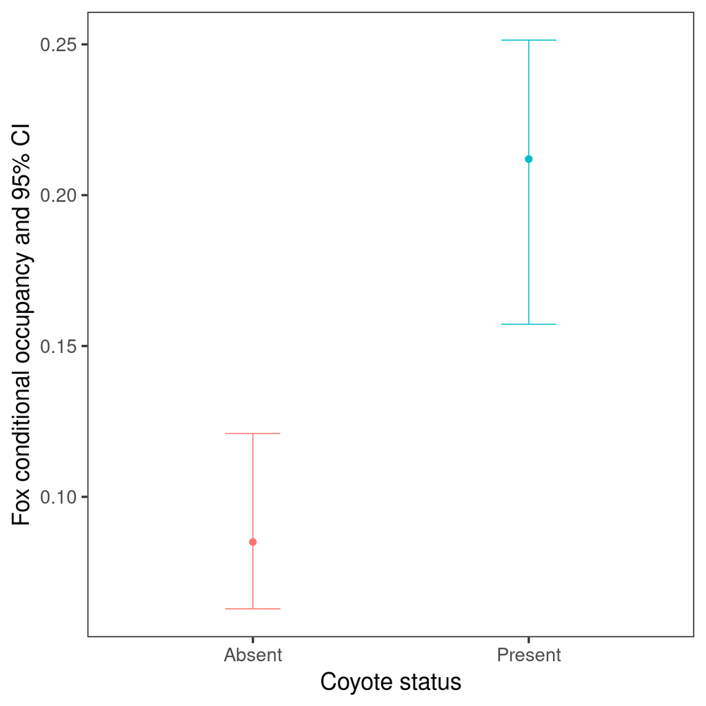

```r
ggplot(data = plot_data, aes(x = Coyote_status, col=Coyote_status)) +
  geom_errorbar(aes(ymin = lower, ymax = upper), width = 0.2) +
  geom_point(aes(y = Predicted), size=3) +
  theme_bw(base_size = 24) +
  theme(panel.grid = element_blank(), legend.position='none') +
  labs(y = "Fox conditional occupancy and 95% CI", x = "Coyote status")
```

### Co-occurence probability

Probability that *both* species 1 and 2 are at a site (or some other arbitrary combo of species)

$$ \psi_{i, fox+coy} = \frac{\psi_{i{11}}}{\psi_{i{11}}+\psi_{i{10}} + \psi_{i{01}} + \psi_{i{00}}}$$

(Trivial for only 2 species)

```r
colnames(occ_prob$Predicted)
```

1. 'psi[11]'

2. 'psi[10]'

3. 'psi[01]'

4. 'psi[00]'

```r
cooccur_manual <- occ_prob$Predicted[,1] / rowSums(occ_prob$Predicted)
head(cooccur_manual)
```

1. 0.0733233311188298

2. 0.0734972660289845

3. 0.0736647950683573

4. 0.0736091636675075

5. 0.0736202170911572

6. 0.0737800289214427

Or with predict:

```r
psi_coccur <- predict(mod_hdens, type="state", species=c("coyote","redfox"))
head(psi_coccur)
```

```
Bootstrapping confidence intervals with 100 samples
```

A data.frame: 6 × 4

|  | Predicted <dbl> | SE <dbl> | lower <dbl> | upper <dbl> |
| --- | --- | --- | --- | --- |
| 1 | 0.07332333 | 0.008831271 | 0.05812770 | 0.09258646 |
| 2 | 0.07349727 | 0.008845090 | 0.05828248 | 0.09277071 |
| 3 | 0.07366480 | 0.008858468 | 0.05843162 | 0.09294809 |
| 4 | 0.07360916 | 0.008854018 | 0.05838208 | 0.09288920 |
| 5 | 0.07362022 | 0.008854901 | 0.05839193 | 0.09290090 |
| 6 | 0.07378003 | 0.008867709 | 0.05853423 | 0.09307006 |

### Plotting covariate effects

To plot the effect of housing density on **marginal** occupancy, we again use `predict`.

1. Generate sequence of housing density values
2. Predict for each value
3. Plot 95% CI and estimate line
1. Generate sequence of possible `Hdens_5km` values for X-axis and put in data frame

NOTE: Even though we scaled this covariate in the analysis, we don't need to manually scale here.

`unmarked` will do it for us because the scaling was specified *in the formula*.

```r
hdens_range <- range(siteCovs(umf)$HDens_5km)
hdens_range
hdens_seq <- seq(hdens_range[1], hdens_range[2], length.out=100)
nd <- data.frame(HDens_5km = hdens_seq)
```

1. 0

2. 186.6694336

2. `predict` occupancy at each value of `Hdens_5km` along our sequence. Supply `nd` to `newdata` argument

We do this for both coyote and red fox separately:

```r
occ_hdens_coy <- predict(mod_hdens, type="state", species="coyote", newdata=nd)
occ_hdens_coy$Species <- "Coyote"

occ_hdens_fox <- predict(mod_hdens, type="state", species="redfox", newdata=nd)
occ_hdens_fox$Species <- "Red fox"
```

```
Bootstrapping confidence intervals with 100 samples

Bootstrapping confidence intervals with 100 samples
```

Then combine the two pieces:

```r
occ_hdens <- rbind(occ_hdens_coy, occ_hdens_fox)
occ_hdens$Hdens_5km = hdens_seq
head(occ_hdens)
```

A data.frame: 6 × 6

|  | Predicted <dbl> | SE <dbl> | lower <dbl> | upper <dbl> | Species <chr> | Hdens_5km <dbl> |
| --- | --- | --- | --- | --- | --- | --- |
| 1 | 0.3415035 | 0.01907380 | 0.3067460 | 0.3768763 | Coyote | 0.000000 |
| 2 | 0.3423496 | 0.01878332 | 0.3083197 | 0.3778287 | Coyote | 1.885550 |
| 3 | 0.3432180 | 0.01853064 | 0.3093056 | 0.3783016 | Coyote | 3.771100 |
| 4 | 0.3441090 | 0.01831743 | 0.3103116 | 0.3785785 | Coyote | 5.656650 |
| 5 | 0.3450230 | 0.01814519 | 0.3113379 | 0.3795972 | Coyote | 7.542199 |
| 6 | 0.3459604 | 0.01801519 | 0.3123849 | 0.3807529 | Coyote | 9.427749 |

3. Make the plot

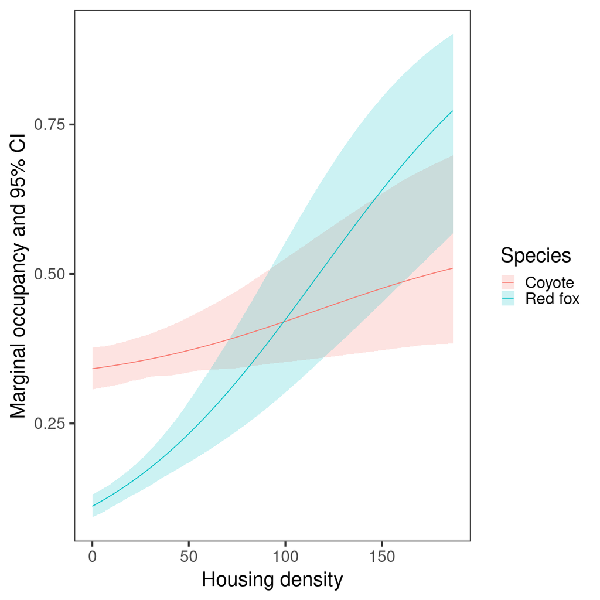

```r
ggplot(data = occ_hdens, aes(x = Hdens_5km)) +
  geom_ribbon(aes(ymin = lower, ymax = upper, fill = Species), alpha = 0.2) +
  geom_line(aes(y = Predicted, col = Species)) +
  theme_bw(base_size = 24) +
  theme(panel.grid = element_blank()) +
  labs(y = "Marginal occupancy and 95% CI", x = "Housing density")
```

### Exercise: Plot conditional occupancy for a covariate

- Plot conditional occupancy of red fox as a function of housing density
- Do this for coyote present, coyote absent, or both (if you have time)
- Should be able to adapt code from previous section on marginal occupancy, just add the `cond` argument.

# Removing interaction terms

(or "forcing interactions to 0")

This is pretty common. The two main reasons:

- 3-way and higher interactions are tough to interpret and rarely part of hypotheses
- Higher-order interactions are hard to estimate

Two options to remove interactions:

- Set corresponding formula to `"0"`
- Set `maxOrder` argument

Setting a formula to `"0"` removes just that particular interaction term.

Review the $f$ design matrix:

```r
umf@fDesign
```

A matrix: 4 × 3 of type dbl

|  | f1[coyote] | f2[redfox] | f3[coyote:redfox] |
| --- | --- | --- | --- |
| psi[11] | 1 | 1 | 1 |
| psi[10] | 1 | 0 | 0 |
| psi[01] | 0 | 1 | 0 |
| psi[00] | 0 | 0 | 0 |

```r
stateformulas_0 <- c("~scale(HDens_5km)", "~scale(HDens_5km)", "0")
mod_noint <- occuMulti(detformulas=detformulas, stateformulas=stateformulas_0, data=umf)
mod_noint
```

```
Call:
occuMulti(detformulas = detformulas, stateformulas = stateformulas_0,
    data = umf, maxOrder = 2L)

Occupancy:
                          Estimate     SE      z  P(>|z|)
[coyote] (Intercept)        -0.631 0.0745  -8.47 2.49e-17
[coyote] scale(HDens_5km)    0.108 0.0628   1.72 8.50e-02
[redfox] (Intercept)        -1.921 0.0998 -19.25 1.52e-82
[redfox] scale(HDens_5km)    0.514 0.0811   6.34 2.27e-10

Detection:
                     Estimate     SE     z  P(>|z|)
[coyote] (Intercept)   -0.332 0.0763 -4.36 1.33e-05
[redfox] (Intercept)   -0.261 0.1195 -2.19 2.87e-02

AIC: 4822.196
```

Setting `maxOrder` gets rid of all interactions of above that level.

For example, `maxOrder = 1` means no interactions at all.

```r
stateformulas <- c("~scale(HDens_5km)", "~scale(HDens_5km)")
mod_noint <- occuMulti(detformulas=detformulas, stateformulas=stateformulas, data=umf, maxOrder=1)
mod_noint
```

```
Call:
occuMulti(detformulas = detformulas, stateformulas = stateformulas,
    data = umf, maxOrder = 1)

Occupancy:
                          Estimate     SE      z  P(>|z|)
[coyote] (Intercept)        -0.631 0.0745  -8.47 2.49e-17
[coyote] scale(HDens_5km)    0.108 0.0628   1.72 8.50e-02
[redfox] (Intercept)        -1.921 0.0998 -19.25 1.52e-82
[redfox] scale(HDens_5km)    0.514 0.0811   6.34 2.27e-10

Detection:
                     Estimate     SE     z  P(>|z|)
[coyote] (Intercept)   -0.332 0.0763 -4.36 1.33e-05
[redfox] (Intercept)   -0.261 0.1195 -2.19 2.87e-02

AIC: 4822.196
```

This is equivalent to fitting two separate occupancy models.

For example, the coyote single-species model:

```r
umf_coy <- unmarkedFrameOccu(y=ylist$coyote, siteCovs=site_covs)
occu(~1~scale(HDens_5km), umf_coy)
```

```
Call:
occu(formula = ~1 ~ scale(HDens_5km), data = umf_coy)

Occupancy:
                 Estimate     SE     z  P(>|z|)
(Intercept)        -0.631 0.0745 -8.47 2.51e-17
scale(HDens_5km)    0.108 0.0628  1.72 8.49e-02

Detection:
 Estimate     SE     z  P(>|z|)
   -0.332 0.0763 -4.36 1.32e-05

AIC: 3245.169
```

### Exercise

- Set up a 3-species model with the `MesoCarnivores` dataset (i.e., add bobcat)
- Add more covariates if you want
- Don't include a 3-species interaction term (i.e., force it to be 0)

# Model fitting challenges

1. Amount of data required
2. Poor estimates

## Amount of data required

- You need a surprising amount of data to have high power to detect interaction effects
- We can explore this with simulation + power analysis

### Quick and very dirty review of power analysis

- Type I error: We reject the null hypothesis when in fact it is true.
- Type II error: We fail to reject the null hypothesis when in fact it is false.
- Power: 1 - Type II error (rule-of-thumb we want > 0.8)
- Power analysis: Determining power for a particular experimental design, effect size, and Type I error ($\alpha$)

We need to use simulation for doing power analysis with this model.

### Power analysis in `unmarked`

Information we need:

- A set of hypothetical effect sizes (= parameter values)
- A "template" model that contains all the information about the experimental design
- Value of $\alpha$ (we'll leave at 0.05)

`unmarked` then automatically:

- Plugs effect sizes (= parameter values) into the template model
- Simulates new datasets and re-fits the models (many times)
- Checks parameter estimates for statistical significance at $\alpha$
- Summarizes the results as power

#### Effect sizes

We define a positive interaction between two species: when species 2 is present, species 1 is twice as likely to occupy a site.

First define $f$ values:

```r
set.seed(123)

f1 <- 0.2
f2 <- 0.1
f12 <- 0.5 # <- EFFECT SIZE OF INTERACTION
```

For illustration, calculate the corresponding occupancy probabilities:

```r
psi <- numeric(4)
psi[1] <- exp(f1 + f2 + f12)
psi[2] <- exp(f1)
psi[3] <- exp(f2)
psi[4] <- 1
psi <- psi / sum(psi)
names(psi) <- c("[11]","[10]","[01]","[00]")
round(psi, 3)
```

**[11]**

0.401

**[10]**

0.22

**[01]**

0.199

**[00]**

0.18

Note probability of both species present [11] is twice as high as either species by itself.

This is a large interaction effect!

#### Simulate a template dataset

Basically, a placeholder dataset with the correct design (number of sites, species, etc)

We can use a more flexible version of the `unmarked` `simulate` method which can simulate datasets from scratch and requires three specific inputs.

1. Model structure / covariates (with formulas)

Two species and no covariates in this example

```r
formulas <- list(
  state = c("~1", "~1", "~1"),
  det = c("~1", "~1")
)
```

2. Experimental design

Number of sites (`M`) and occasions (`J`)

```r
design <- list(M = 700, J = 5)
```

3. Coefficient values for state and det models

The coefficient values don't actually matter for this "template" dataset (as they are later replaced with the effect sizes we choose), but we'll use the ones we specified above

```r
# Coefficient values
coef <- list(state = c(f1, f2, f12), det = c(0, 0))
```

Finally, simulate the dataset:

```r
umf_temp <- simulate("occuMulti", formula = formulas, design = design, coef = coef)
head(umf_temp)
```

```
Data frame representation of unmarkedFrame object.
Only showing observation matrix for species 1.
   y.1 y.2 y.3 y.4 y.5
1    1   0   0   1   0
2    0   0   0   0   0
3    1   1   0   0   0
4    0   0   0   0   0
5    0   0   0   0   0
6    1   1   1   1   0
7    0   0   0   1   0
8    0   0   0   0   0
9    0   1   1   1   1
10   1   1   1   1   0
```

### Create template model

Fit a model using our template dataset.

Remember, the actual estimates from this model don't matter, just the structure of the model (sample size, covariates included, etc.)

```r
fit_temp <- occuMulti(detformulas = formulas$det, stateformulas = formulas$state, umf_temp)
```

## Run power analysis

Required info:

1. The template model (to tell `unmarked` about the study design etc.)
2. Effect sizes to get power for (called `coefs`)
3. Value of $\alpha$ if we want something other than 0.05

Here's the 'true' effect sizes we specified earlier (we're focused on the interaction effect size, 0.5)

```r
effects <- list(state = c(f1, f2, f12), det = c(0, 0))
effects
```

**$state**

1. 0.2

2. 0.1

3. 0.5

**$det**

1. 0

2. 0

Now run the power analysis with the `powerAnalysis` function.

This is the power at the sample size we specified (700 sites)

```r
pa700 <- powerAnalysis(fit_temp, coefs = effects) # coef = effect sizes to test
pa700
```

```
Model:
occuMulti(detformulas = formulas$det, stateformulas = formulas$state,
    data = umf_temp, maxOrder = 2L)

Power Statistics:
 Submodel             Parameter Effect Null Power
    state     [sp1] (Intercept)    0.2    0  0.34
    state     [sp2] (Intercept)    0.1    0  0.08
    state [sp1:sp2] (Intercept)    0.5    0  0.86
      det     [sp1] (Intercept)    0.0    0  0.00
      det     [sp2] (Intercept)    0.0    0  0.00
```

We can also test smaller sample sizes using the `design` argument, which randomly sub-samples the existing sites:

```r
pa500 <- powerAnalysis(fit_temp, coefs = coef, design = list(M=500, J=5))
pa300 <- powerAnalysis(fit_temp, coefs = coef, design = list(M=300, J=5))
pa100 <- powerAnalysis(fit_temp, coefs = coef, design = list(M=100, J=5))
```

Finally, combine all the power analyses into a list for comparison and plot power for the interaction term.

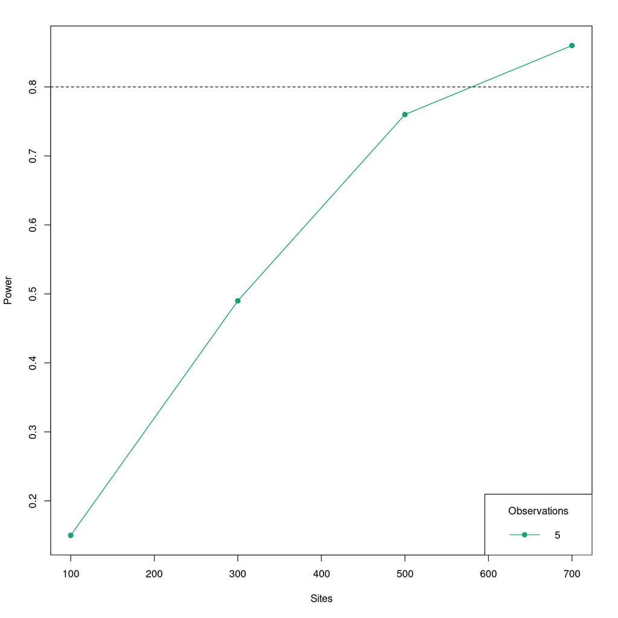

```r
pl <- unmarkedPowerList(list(pa100, pa300, pa500, pa700))

plot(pl, param = "[sp1:sp2] (Intercept)", power=0.8)
```

We need quite a few sites (~700) to have adequate power to detect a significant positive interaction, even when the effect size is relatively large!

I think many studies using this model are significantly under-powered.

## Poor estimates

- You might get poor estimates under certain conditions:
  - Sparse data (many 0s)
  - Boundary estimates (occupancy close to 0 or 1)
  - Few observations where multiple species are detected
  - Separation (perfect correlation with covariate)
- What do I mean by poor estimates? Very large absolute values and SEs

```r
state_complex <- c(rep("~scale(Dist_5km)+scale(HDens_5km)", 6), 0)
det_complex <- rep("~Trail",3)

mod_complex <- occuMulti(stateformulas=state_complex, detformulas=det_complex, umf)
mod_complex
```

```
Call:
occuMulti(detformulas = det_complex, stateformulas = state_complex,
    data = umf, maxOrder = 3L)

Occupancy:
                                 Estimate     SE      z  P(>|z|)
[bobcat] (Intercept)             -23.0171  5.787 -3.977 6.97e-05
[bobcat] scale(Dist_5km)          -2.4249  0.689 -3.518 4.34e-04
[bobcat] scale(HDens_5km)        -82.3836 19.799 -4.161 3.17e-05
[coyote] (Intercept)              -0.6789  0.225 -3.017 2.55e-03
[coyote] scale(Dist_5km)          -0.0176  0.139 -0.127 8.99e-01
[coyote] scale(HDens_5km)         -0.5534  0.748 -0.740 4.59e-01
[redfox] (Intercept)              -1.3946  0.257 -5.425 5.79e-08
[redfox] scale(Dist_5km)          -0.5293  0.250 -2.114 3.45e-02
[redfox] scale(HDens_5km)          0.2108  0.261  0.808 4.19e-01
[bobcat:coyote] (Intercept)        6.7598  6.390  1.058 2.90e-01
[bobcat:coyote] scale(Dist_5km)    1.6979  0.695  2.444 1.45e-02
[bobcat:coyote] scale(HDens_5km)  17.9202 21.460  0.835 4.04e-01
[bobcat:redfox] (Intercept)       15.3983  3.461  4.449 8.64e-06
[bobcat:redfox] scale(Dist_5km)    0.8836  0.439  2.014 4.40e-02
[bobcat:redfox] scale(HDens_5km)  64.1330 12.375  5.182 2.19e-07
[coyote:redfox] (Intercept)        1.1084  0.363  3.050 2.29e-03
[coyote:redfox] scale(Dist_5km)    0.1149  0.340  0.338 7.35e-01
[coyote:redfox] scale(HDens_5km)   0.9046  0.781  1.159 2.47e-01

Detection:
                     Estimate     SE      z  P(>|z|)
[bobcat] (Intercept)    -2.83 0.1419 -19.91 3.12e-88
[bobcat] Trail           1.74 0.1542  11.26 2.10e-29
[coyote] (Intercept)    -1.96 0.0984 -19.88 5.90e-88
[coyote] Trail           2.17 0.1220  17.75 1.63e-70
[redfox] (Intercept)    -1.59 0.1601  -9.93 2.97e-23
[redfox] Trail           1.78 0.1997   8.93 4.12e-19

AIC: 5958.196
```

### Potential Solutions

- Fewer covariates
- Fewer species
- Adjust observation period length if possible
- Set higher-order interaction terms to 0
- Penalized likelihood with `optimizePenalty` function (Clipp et al. 2021)
- Bayesian framework

### Penalized likelihood

"Bayes-inspired" penalty (Hutchinson et al. 2015):

$$ -\lambda\frac{1}{2}\sum_i{}\theta_i^2 $$

Where $\theta$ is the vector of parameter estimates.

Size of penalty increases as values of $\theta$ increase.

Tradeoff:

- Introduce small bias in parameter estimates
- Potentially large reduction in variance

```
mod_penalty <- occuMulti(stateformulas=state_complex, detformulas=det_complex, umf, penalty=1)
mod_penalty
```

```
Bootstraping covariance matrix


Call:
occuMulti(detformulas = det_complex, stateformulas = state_complex,
    data = umf, penalty = 1, maxOrder = 3L)

Occupancy:
                                 Estimate    SE      z  P(>|z|)
[bobcat] (Intercept)              -1.7810 0.269 -6.627 3.43e-11
[bobcat] scale(Dist_5km)          -1.3143 0.293 -4.491 7.08e-06
[bobcat] scale(HDens_5km)         -2.8200 0.539 -5.230 1.70e-07
[coyote] (Intercept)              -0.6049 0.214 -2.830 4.66e-03
[coyote] scale(Dist_5km)           0.0285 0.106  0.270 7.87e-01
[coyote] scale(HDens_5km)         -1.0908 0.378 -2.887 3.88e-03
[redfox] (Intercept)              -1.5659 0.305 -5.140 2.75e-07
[redfox] scale(Dist_5km)          -0.3068 0.157 -1.958 5.02e-02
[redfox] scale(HDens_5km)          0.4730 0.546  0.867 3.86e-01
[bobcat:coyote] (Intercept)        1.1871 0.434  2.736 6.22e-03
[bobcat:coyote] scale(Dist_5km)    0.9347 0.346  2.705 6.84e-03
[bobcat:coyote] scale(HDens_5km)  -0.3218 1.008 -0.319 7.50e-01
[bobcat:redfox] (Intercept)       -0.8831 0.347 -2.545 1.09e-02
[bobcat:redfox] scale(Dist_5km)    0.0364 0.305  0.119 9.05e-01
[bobcat:redfox] scale(HDens_5km)   2.5609 1.074  2.384 1.71e-02
[coyote:redfox] (Intercept)        1.0001 0.310  3.227 1.25e-03
[coyote:redfox] scale(Dist_5km)    0.0236 0.167  0.141 8.87e-01
[coyote:redfox] scale(HDens_5km)   1.3920 0.345  4.030 5.57e-05

Detection:
                     Estimate     SE      z  P(>|z|)
[bobcat] (Intercept)    -2.44 0.1755 -13.89 7.63e-44
[bobcat] Trail           1.74 0.1966   8.87 7.25e-19
[coyote] (Intercept)    -1.89 0.0926 -20.45 5.64e-93
[coyote] Trail           2.10 0.1179  17.84 3.31e-71
[redfox] (Intercept)    -1.49 0.1782  -8.35 6.64e-17
[redfox] Trail           1.72 0.1714  10.04 9.73e-24

AIC: 6135.555
```

How to choose penalty value? `optimizePenalty()` function.

```
mod_penalty <- optimizePenalty(mod_complex, penalties=c(0.5,1))
```

### Literature Cited

Clipp, H.L., Evans, A.L., Kessinger, B.E., Kellner, K. and Rota, C.T. (2021). A penalized likelihood for multispecies occupancy models improves predictions of species interactions. Ecology, p.e03520.

Rota, C.T., Ferreira, M.A., Kays, R.W., Forrester, T.D., Kalies, E.L., McShea, W.J., Parsons, A.W. and Millspaugh, J.J. (2016). A multispecies occupancy model for two or more interacting species. Methods in Ecology and Evolution, 7(10), pp.1164-1173.